# A importância da Estatística Espacial na pesquisa eleitoral

Marcelo José Martins Jr

# Como funcionam as pesquisas?

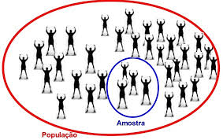

Diferentemente de um censo, na qual toda a população participa, a pesquisa eleitoral seleciona apenas um grupo de pessoas (amostra) que melhor descreve o setor de estudo. Os setores são censitários em que as entrevistas serão realizadas, estas zonas são unidades territoriais para fins de levantamentos de dados, para o estudo ser correto essas delimitações territoriais são sorteadas e recebem a pesquisa.

# Por que nunca sou entrevistado?

[figure not shown]

Nesse processo o pesquisador utiliza de métodos de amostragem para selecionar quais categorias da população devem ser consideradas no estudo, sendo assim a pesquisa é feita analisando essas características (variáveis). Então se o Brasil é composto por mais mulheres que homens, essa pesquisa deve se ter mais entrevistas com mulheres, isso serve tanto para escolaridade, renda, entre outros. Coletado tudo isso, dizemos então que esses dados de uma amostra abrangente descreve todo o territorio delimitado.

Como o conceito de amostragem é muito complexo e o post não visa entrar em detalhes, se o leitor quiser entender um pouco sobre esse assunto pode consultar o post do petiano Jeová, que trata com maior riqueza do assunto.

# Utilizando a Estatística Espacial numa pesquisa eleitoral

O estudo de eleições pode ser feito em três escalas: a que trata do eleitor individual; a que utiliza comportamento agregado de eleitores em espaços delimitados dentro de um país; e as análises feitas entre nações. A Geografia Eleitoral se encaixa na segunda escala. Infelizmente, no Brasil a aplicação de estatística espacial se restringe a um número muito baixo de publicações, sendo assim é difícil ver a distribuição das pesquisas eleitorais num mapa do país.

Geografia Eleitoral trata de temas de notável importância, com ligações objetivas com problemas de democracia os trabalhos da área, de maneira geral, podem ser divididos em três linhas: estudos dos efeitos da composição dos espaços; estudos dos efeitos do contexto na definição de comportamento social e; estudos dos efeitos da organização territorial dos sistemas eleitorais. A aplicação de Geografia Eleitoral na Ciência Política do Brasil pode ser dividida em dois grandes temas: um que utiliza o espaço para explorar temas relativos à representação e consequências de regras eleitorais, usando os padrões territoriais de voto no espectro concentrado-disperso; outro que associa variáveis contextuais e composicionais às divulgações de resultados eleitorais, tratando de estruturas macro de comportamento eleitoral.

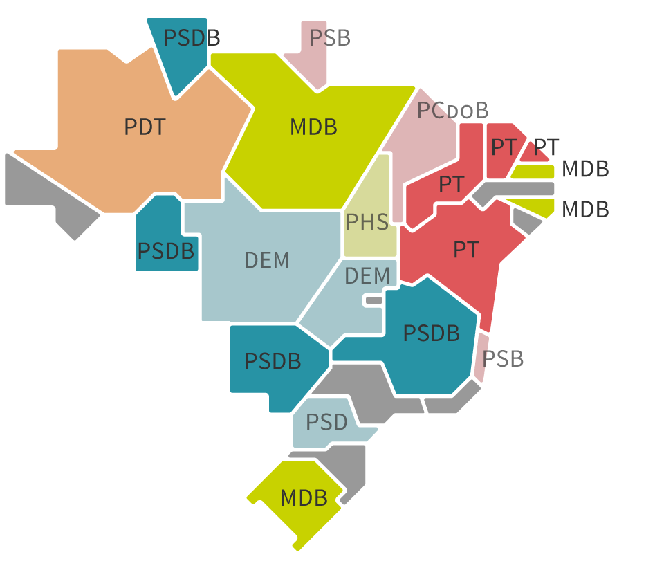

Mapa do Ibope para governador no Brasil segundo as pesquisas de Agosto de 2018

# Importância da Estatística Espacial para uma pesquisa eleitoral

Com a estatística espacial podemos analisar padrões sociopolíticos ocultos nessa massa de dados disponíveis, a linha de pesquisa é sub-estudada frente à disponibilidade de dados e potencialidade das explorações.A análise espacial pode parecer complexa, entretanto os avanços tecnológicos e a disponibilidade de dados georreferenciados permitem, de modo relativamente simples, o acesso à modelagem espacial e procedimentos de estimação e métodos de inferência.

# Referências

[Geografia eleitoral precisa de você](http://www.cpop.ufpr.br/cpop/posts/a-geografia-eleitoral-precisa-de-voce)

[Geoprocessamento-UFMG](http://www.csr.ufmg.br/geoprocessamento/publicacoes/estespacial.pdf)

[Como são feitas as pesquisas eleitorais](https://www.politize.com.br/pesquisas-eleitorais-como-sao-feitas/)

Conceitos Básicos de Amostragem

[figure not shown]